# Snow Gauge Calibration

Lu Xu and Zehui Zhang

# 2. Basic Analysis

So as to determine a deoth profile of snow density, in this case, we will develop a procedure to calibrate the snow gauge from data

Open the data set

```r
setwd("~/Downloads")
dat <- read.table("gauge.txt", header=TRUE)
```

### 2.1 Raw Data

By using R, fit this data set to a liner regression model, and plot it out. Then check if the transformation needs.

Make the sactterplot and the best fit linear regression line

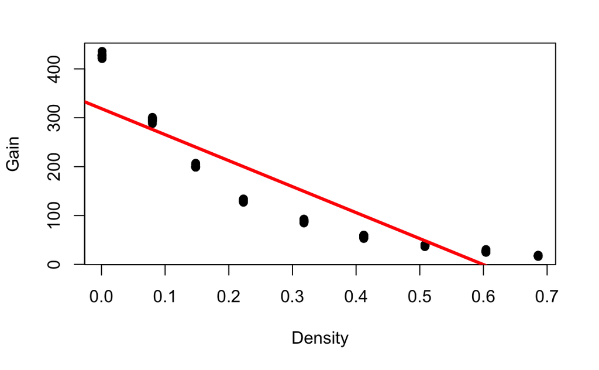

```r
# sactter plot and the linear regression model
plot(dat$gain ~ dat$density, ylab = "Gain", xlab = "Density",pch = 19)
Lm = lm(dat$gain ~ dat$density, data = dat)
abline(Lm,col = 'red',lwd = 3)
```

```r
summary(Lm)
```

```
Call:
lm(formula = dat$gain ~ dat$density, data = dat)

Residuals:
   Min     1Q Median     3Q    Max
-73.08 -44.29  -9.72  30.82 117.83

Coefficients:
            Estimate Std. Error t value Pr(>|t|)
(Intercept)   318.70      10.79   29.54   <2e-16 ***
dat$density  -531.95      26.95  -19.73   <2e-16 ***
---
Signif. codes:  0 ‘***’ 0.001 ‘**’ 0.01 ‘*’ 0.05 ‘.’ 0.1 ‘ ’ 1

Residual standard error: 57.54 on 88 degrees of freedom
Multiple R-squared:  0.8157,    Adjusted R-squared:  0.8136
F-statistic: 389.5 on 1 and 88 DF,  p-value: < 2.2e-16
```

Make the residual plot

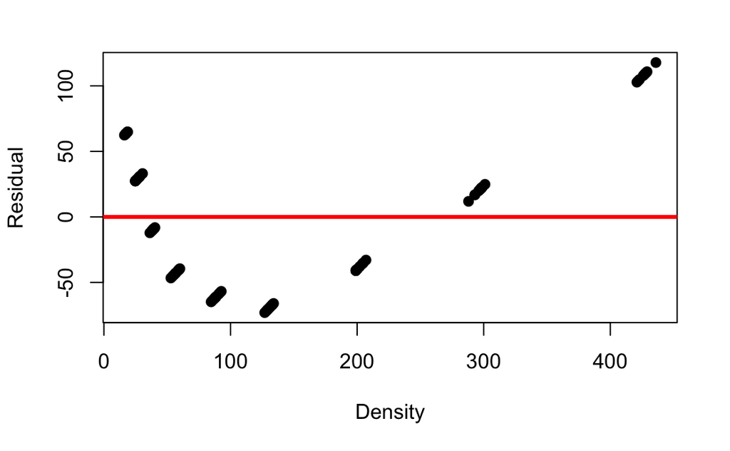

```r
plot(residuals(Lm) ~ dat$gain, ylab = "Residual", xlab = 'Density',pch =19)
abline(h = 0,col = 'red',lwd = 3)
```

By making the histogram and the qq plot of the residual, it is efficient to check if the transformation needed.

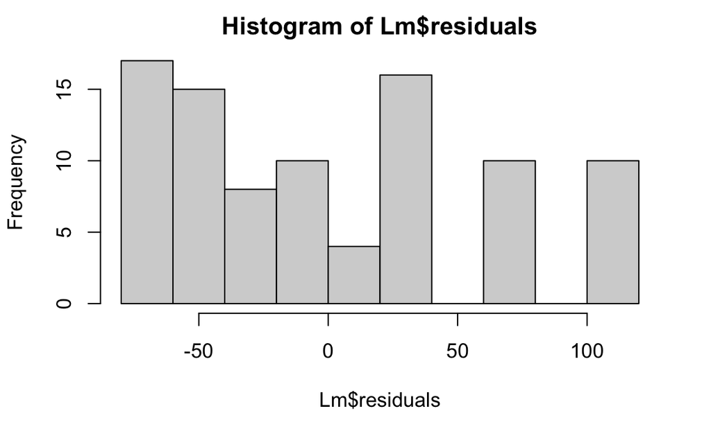

```r
hist(Lm$residuals)
```

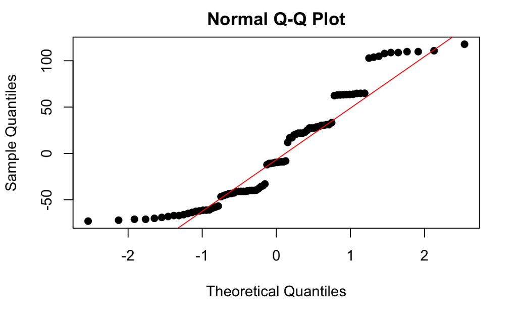

```r
qqnorm(Lm$residuals,pch = 19)
qqline(Lm$residuals,col = "red")
```

### 2.2 Transformation of Data

Based on the work in the 2.1 section, we found that the transformation is necessary. In this part, we will transform the data into an appropriate model and justify this model is appropriate one.

Log Transformation

```r
gain = dat$gain
density = dat$density
Logm = lm(log(gain) ~ density, data = dat)
summary(Logm)
```

```
Call:
lm(formula = log(gain) ~ density, data = dat)

Residuals:
      Min        1Q    Median        3Q       Max
-0.131216 -0.052396 -0.004436  0.054607  0.202447

Coefficients:
            Estimate Std. Error t value Pr(>|t|)
(Intercept)  5.99727    0.01274   470.8   <2e-16 ***
density     -4.60594    0.03182  -144.8   <2e-16 ***
---
Signif. codes:  0 ‘***’ 0.001 ‘**’ 0.01 ‘*’ 0.05 ‘.’ 0.1 ‘ ’ 1

Residual standard error: 0.06792 on 88 degrees of freedom
Multiple R-squared:  0.9958,    Adjusted R-squared:  0.9958
F-statistic: 2.096e+04 on 1 and 88 DF,  p-value: < 2.2e-16
```

Make the scatter plot after transformation

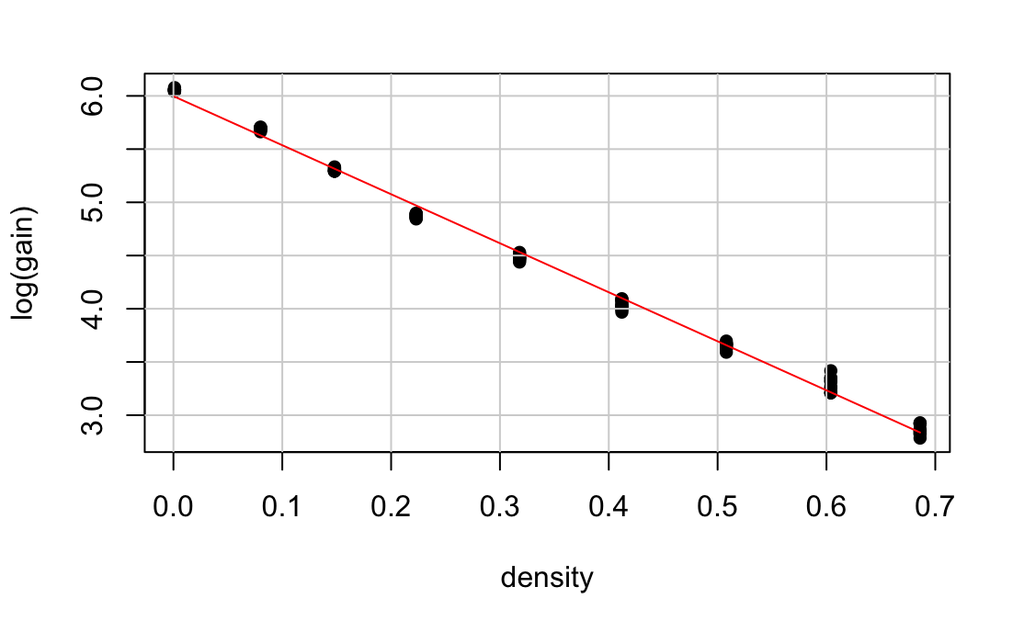

```r
plot(log(gain) ~ density, data = dat, pch = 16) ; grid(lty='solid')
lines(predict(Logm) ~ density, data = dat, pch = 16, col = "red")
```

Plot the residual plot

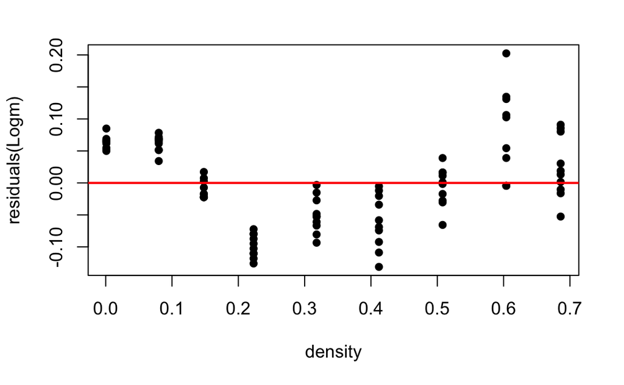

```r
plot(residuals(Logm) ~ density, data = dat, pch = 16)
abline(h = 0, lwd = 2, col = "red")
```

```r
hist(residuals(Logm))
qqnorm(Logm$residuals,pch = 19)
qqline(Logm$residuals,col = "red")
```

[output not shown]

### 2.3 Robustness

Due to the densities of the polyethylene blocks are not reported exactly, we will do the simulation study by add a random error into the data set for both linear model and the transformed model.

Add the random error to the original density Data set 1

```r
new_dat1 = jitter(density, factor = 1, amount = NULL)
dat$new_data1 = new_dat1
ndensity1 = dat$new_data1
```

Data set 2

```r
new_dat2 = jitter(density, factor = 1, amount = NULL)
dat$new_data2 = new_dat2
ndensity2 = dat$new_data2
```

Simulation study for the linear model

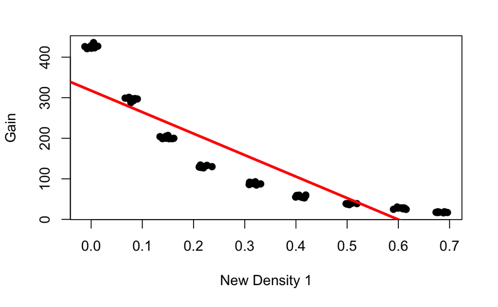

```r
# For data set 1
plot(dat$gain ~ ndensity1, ylab = "Gain", xlab = "New Density 1",pch = 19)
nLm1 = lm(dat$gain ~ ndensity1, data = dat)
abline(nLm1,col = 'red',lwd = 3)
```

```r
summary(nLm1)
```

```
Call:
lm(formula = dat$gain ~ ndensity1, data = dat)

Residuals:
   Min     1Q Median     3Q    Max
-76.70 -46.97 -12.55  33.29 120.96

Coefficients:
            Estimate Std. Error t value Pr(>|t|)
(Intercept)   317.57      10.90   29.12   <2e-16 ***
ndensity1    -530.08      27.29  -19.43   <2e-16 ***
---
Signif. codes:  0 ‘***’ 0.001 ‘**’ 0.01 ‘*’ 0.05 ‘.’ 0.1 ‘ ’ 1

Residual standard error: 58.28 on 88 degrees of freedom
Multiple R-squared:  0.8109,    Adjusted R-squared:  0.8088
F-statistic: 377.4 on 1 and 88 DF,  p-value: < 2.2e-16
```

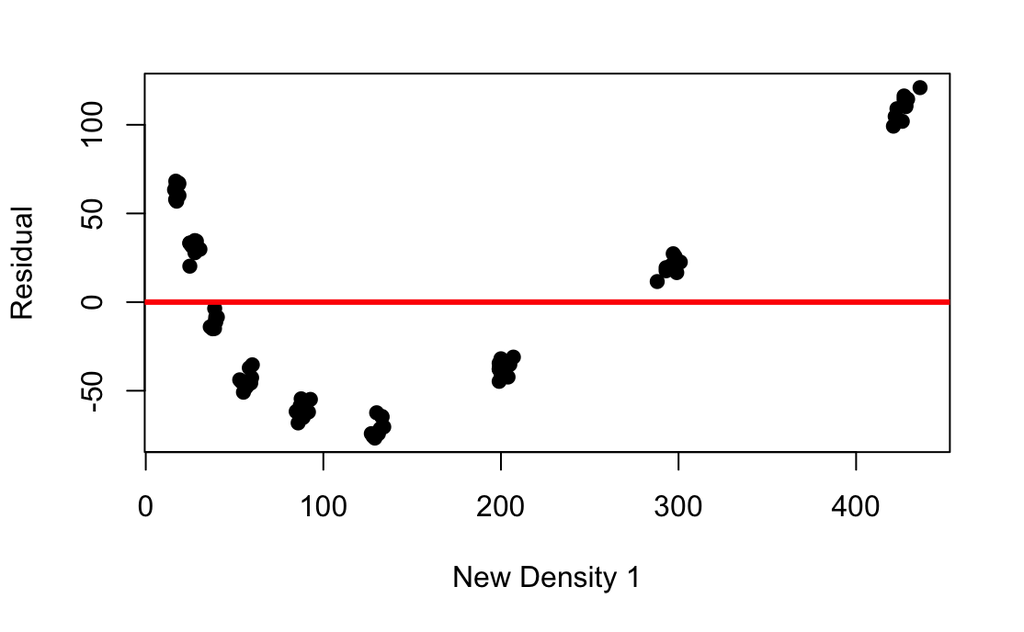

```r
plot(residuals(nLm1) ~ dat$gain, ylab = "Residual", xlab = 'New Density 1',pch =19)
abline(h = 0,col = 'red',lwd = 3)
```

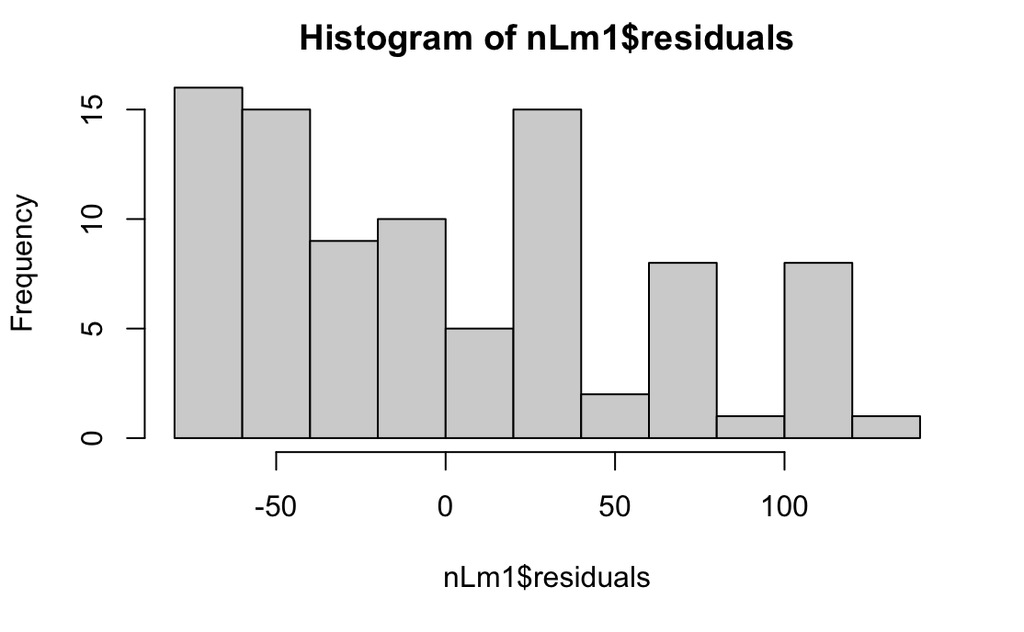

```r
hist(nLm1$residuals)
```

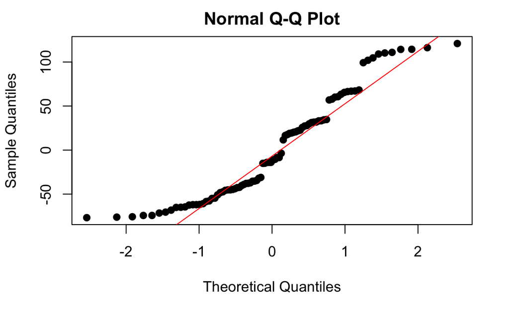

```r
qqnorm(nLm1$residuals,pch = 19)
qqline(nLm1$residuals,col = "red")
```

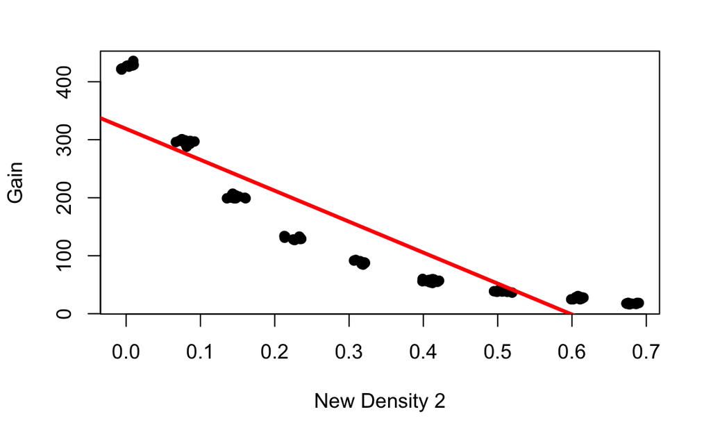

```r
# for data set 2
plot(dat$gain ~ ndensity2, ylab = "Gain", xlab = "New Density 2",pch = 19)
nLm2 = lm(dat$gain ~ ndensity2, data = dat)
abline(nLm2,col = 'red',lwd = 3)
```

```r
summary(nLm2)
```

```
Call:
lm(formula = dat$gain ~ ndensity2, data = dat)

Residuals:
   Min     1Q Median     3Q    Max
-74.08 -47.07 -11.63  36.05 122.19

Coefficients:
            Estimate Std. Error t value Pr(>|t|)
(Intercept)   318.93      10.81   29.52   <2e-16 ***
ndensity2    -533.82      27.06  -19.73   <2e-16 ***
---
Signif. codes:  0 ‘***’ 0.001 ‘**’ 0.01 ‘*’ 0.05 ‘.’ 0.1 ‘ ’ 1

Residual standard error: 57.56 on 88 degrees of freedom
Multiple R-squared:  0.8155,    Adjusted R-squared:  0.8134
F-statistic: 389.1 on 1 and 88 DF,  p-value: < 2.2e-16
```

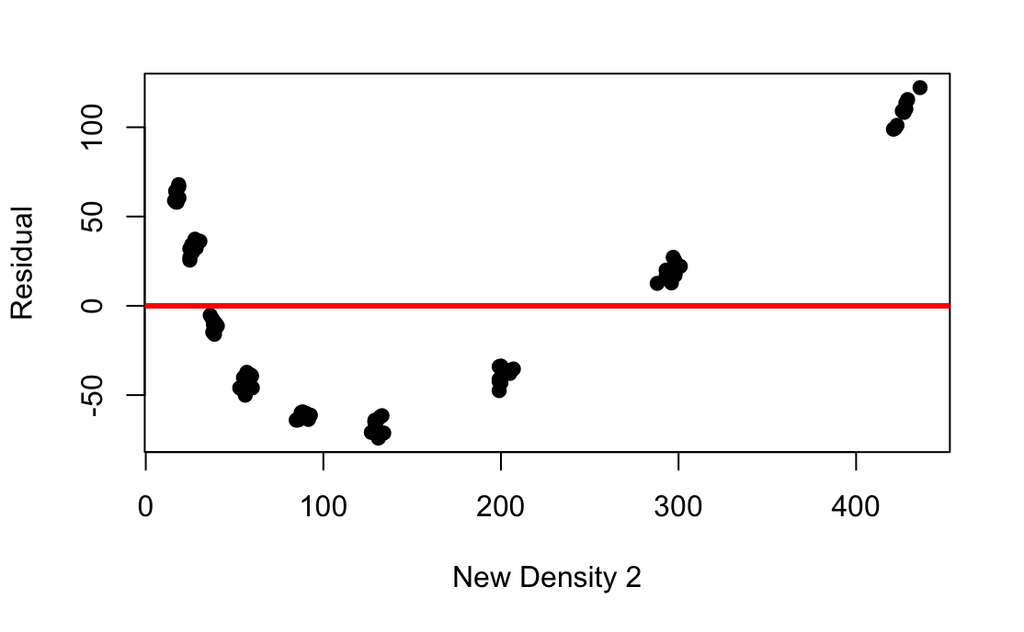

```r
plot(residuals(nLm2) ~ dat$gain, ylab = "Residual", xlab = 'New Density 2',pch =19)
abline(h = 0,col = 'red',lwd = 3)
```

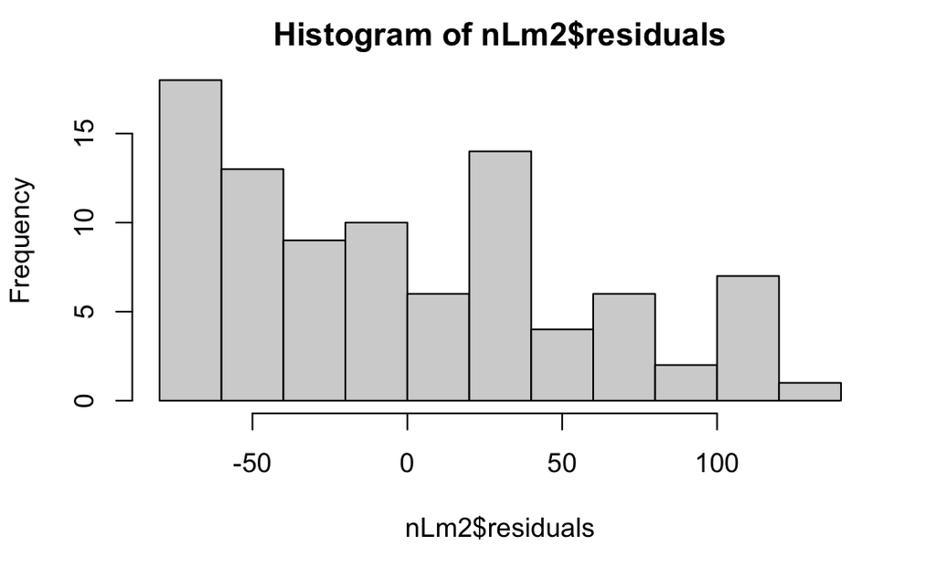

```r
hist(nLm2$residuals)
```

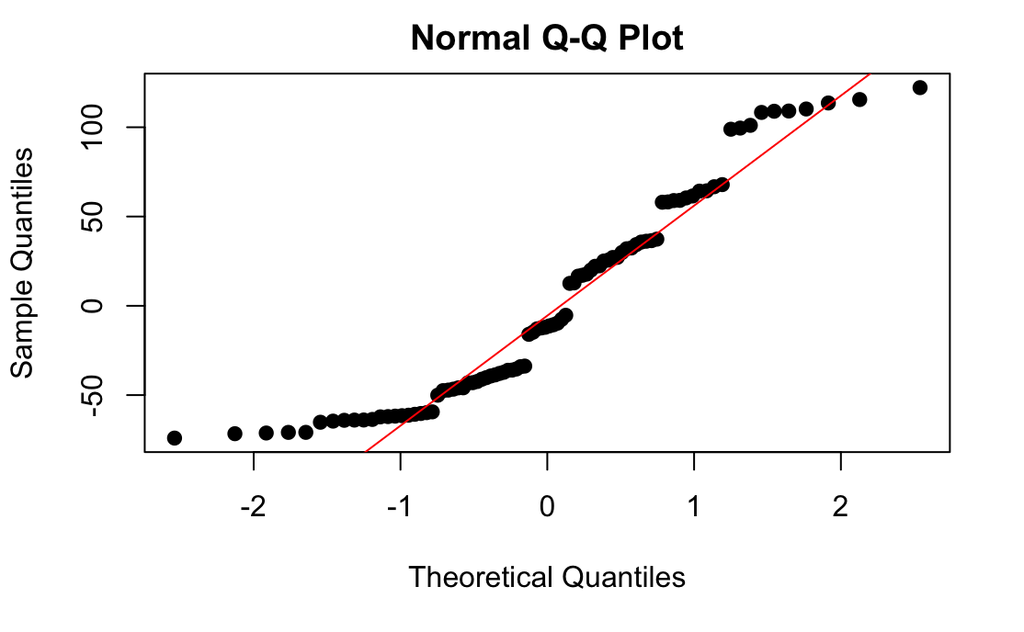

```r
qqnorm(nLm2$residuals,pch = 19)
qqline(nLm2$residuals,col = "red")
```

Simulation study for log model

```r
# For Data Set 1
nLogm1 = lm(log(gain) ~ ndensity1, data = dat)
summary(nLogm1)
```

```
Call:
lm(formula = log(gain) ~ ndensity1, data = dat)

Residuals:
      Min        1Q    Median        3Q       Max
-0.160201 -0.058315  0.004187  0.056089  0.176415

Coefficients:
            Estimate Std. Error t value Pr(>|t|)
(Intercept)  5.99062    0.01510   396.8   <2e-16 ***
ndensity1   -4.59926    0.03778  -121.7   <2e-16 ***
---
Signif. codes:  0 ‘***’ 0.001 ‘**’ 0.01 ‘*’ 0.05 ‘.’ 0.1 ‘ ’ 1

Residual standard error: 0.0807 on 88 degrees of freedom
Multiple R-squared:  0.9941,    Adjusted R-squared:  0.994
F-statistic: 1.482e+04 on 1 and 88 DF,  p-value: < 2.2e-16
```

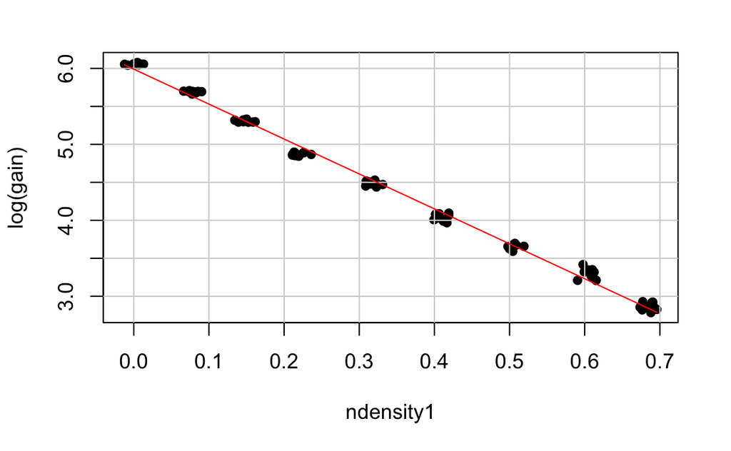

```r
plot(log(gain) ~ ndensity1, data = dat, pch = 16) ; grid(lty='solid')
lines(predict(nLogm1) ~ ndensity1, data = dat, pch = 16, col = "red")
```

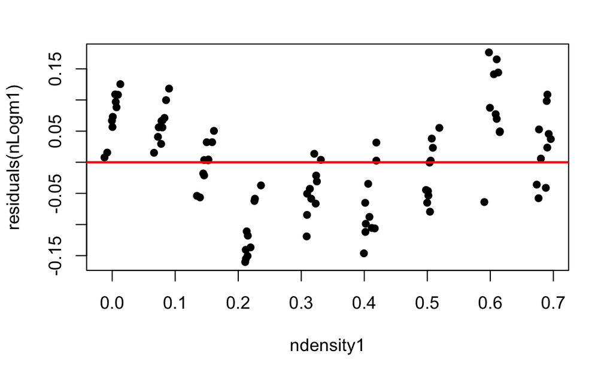

```r
plot(residuals(nLogm1) ~ ndensity1, data = dat, pch = 16)
abline(h = 0, lwd = 2, col = "red")
```

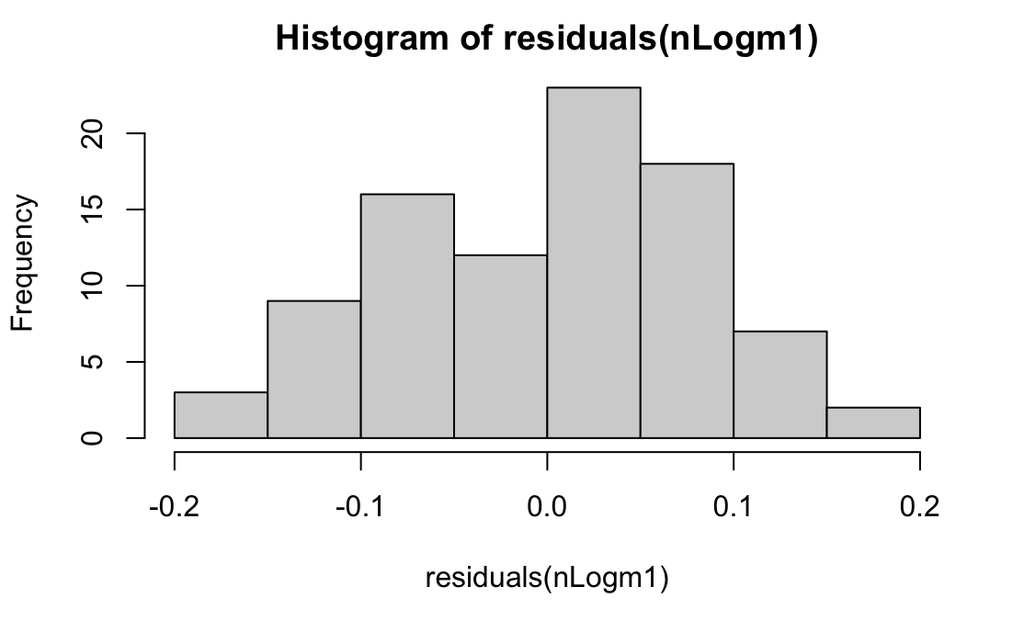

```r
hist(residuals(nLogm1))
```

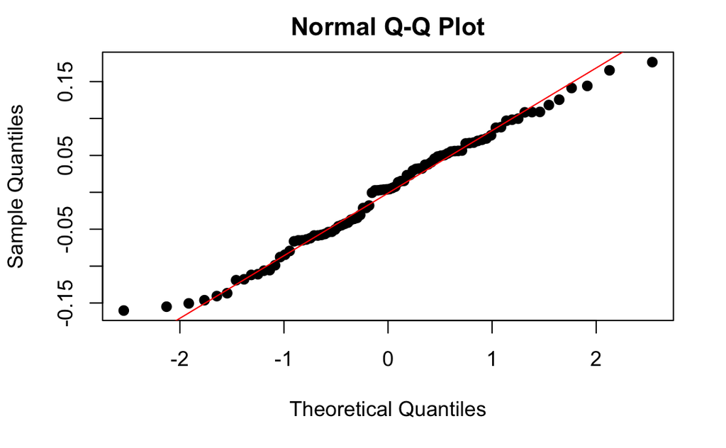

```r
qqnorm(nLogm1$residuals,pch = 19)
qqline(nLogm1$residuals,col = "red")
```

```r
# For Data Set 2
nLogm2 = lm(log(gain) ~ ndensity2, data = dat)
summary(nLogm2)
```

```
Call:
lm(formula = log(gain) ~ ndensity2, data = dat)

Residuals:
     Min       1Q   Median       3Q      Max
-0.13800 -0.05271 -0.00722  0.04753  0.22848

Coefficients:
            Estimate Std. Error t value Pr(>|t|)
(Intercept)  5.99855    0.01426   420.6   <2e-16 ***
ndensity2   -4.62015    0.03572  -129.3   <2e-16 ***
---
Signif. codes:  0 ‘***’ 0.001 ‘**’ 0.01 ‘*’ 0.05 ‘.’ 0.1 ‘ ’ 1

Residual standard error: 0.07598 on 88 degrees of freedom
Multiple R-squared:  0.9948,    Adjusted R-squared:  0.9947
F-statistic: 1.673e+04 on 1 and 88 DF,  p-value: < 2.2e-16
```

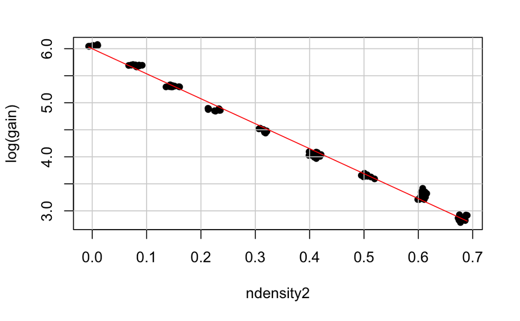

```r
plot(log(gain) ~ ndensity2, data = dat, pch = 16) ; grid(lty='solid')
lines(predict(nLogm2) ~ ndensity2, data = dat, pch = 16, col = "red")
```

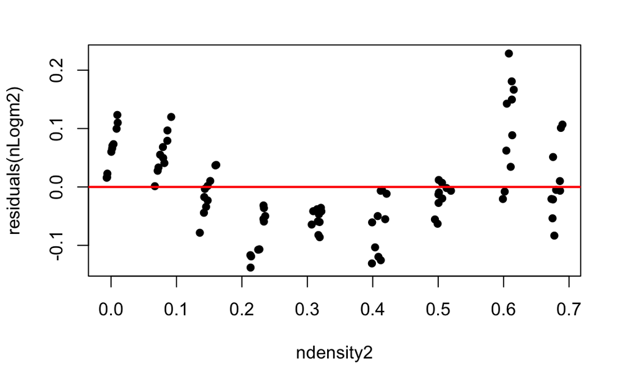

```r
plot(residuals(nLogm2) ~ ndensity2, data = dat, pch = 16)
abline(h = 0, lwd = 2, col = "red")
```

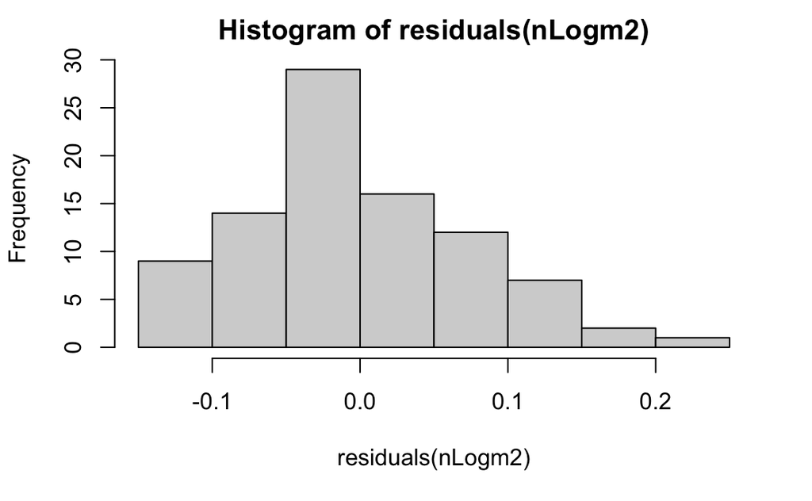

```r
hist(residuals(nLogm2))
```

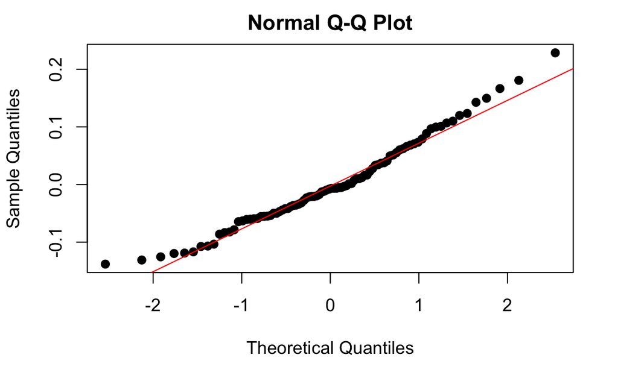

```r
qqnorm(nLogm2$residuals,pch = 19)
qqline(nLogm2$residuals,col = "red")
```

### 2.4 Forward prediction

Produce point estimates and uncertainty bands for gains, specifically, 0.508, 0.001

```r
# Prediction bounds
p1<-predict(Logm,newdata = data.frame(density = unique(density)), interval ="prediction")
p1
```

```
       fit      lwr      upr
1 2.837593 2.700029 2.975156
2 3.215280 3.078466 3.352093
3 3.657450 3.521268 3.793631
4 4.099619 3.963802 4.235437
5 4.532578 4.396854 4.668301
6 4.970142 4.834248 5.106035
7 5.315587 5.179373 5.451801
8 5.628791 5.492144 5.765437
9 5.992660 5.855343 6.129976
```

```r
dat2 <- data.frame(density = density,log = log(gain))
plot(dat2,pch = 19)
abline(Logm)
```

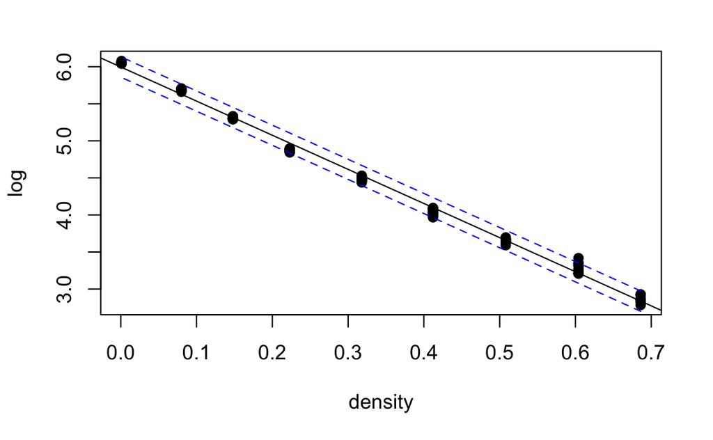

```r
lines(p1[,2]~ unique(density),lty = 2,col = "blue")
lines(p1[,3]~ unique(density),lty = 2,col = "blue")
```

```r
#0.508
pred1 = predict(Logm,newdata = data.frame(density = 0.508),interval = "prediction")
exp(pred1)
```

```
       fit      lwr      upr
1 38.76236 33.82731 44.41737
```

```r
#0.001
pred2 = predict(Logm,newdata = data.frame(density = 0.001),interval = "prediction")
exp(pred2)
```

```
       fit      lwr      upr
1 400.4783 349.0946 459.4253
```

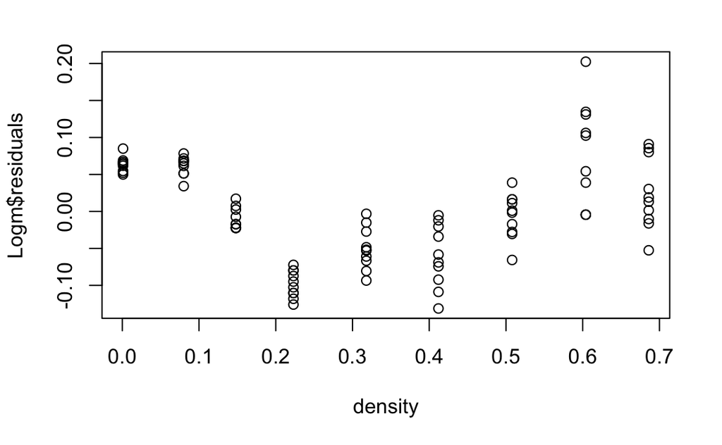

```r
# residuals
plot(Logm$residuals ~ density)
```

### 2.5 Reverse prediction prediction

Invert the forward prediction made in previous part, and check the corresponding gain of the real density value.

```r
# Invert model
iLogm = lm(log(density) ~ gain, data = dat)
summary(iLogm)
```

```
Call:
lm(formula = log(density) ~ gain, data = dat)

Residuals:
    Min      1Q  Median      3Q     Max
-1.3279 -0.2491 -0.2061  0.1932  1.4364

Coefficients:
            Estimate Std. Error t value Pr(>|t|)
(Intercept)  0.09586    0.10706   0.895    0.373
gain        -0.01348    0.00055 -24.511   <2e-16 ***
---
Signif. codes:  0 ‘***’ 0.001 ‘**’ 0.01 ‘*’ 0.05 ‘.’ 0.1 ‘ ’ 1

Residual standard error: 0.6915 on 88 degrees of freedom
Multiple R-squared:  0.8722,    Adjusted R-squared:  0.8708
F-statistic: 600.8 on 1 and 88 DF,  p-value: < 2.2e-16
```

```r
newdensity = data.frame(gain = c(38.6,426.7))
p2 <- predict(iLogm,newdata = newdensity, interval ="prediction")
exp(p2)
```

```
          fit          lwr        upr
1 0.654081341 0.1634753643 2.61704510
2 0.003494011 0.0008476183 0.01440284
```

```r
dat3 <- data.frame(gain = gain, density = log(density))
plot(dat3,pch = 19)
abline(iLogm)
```

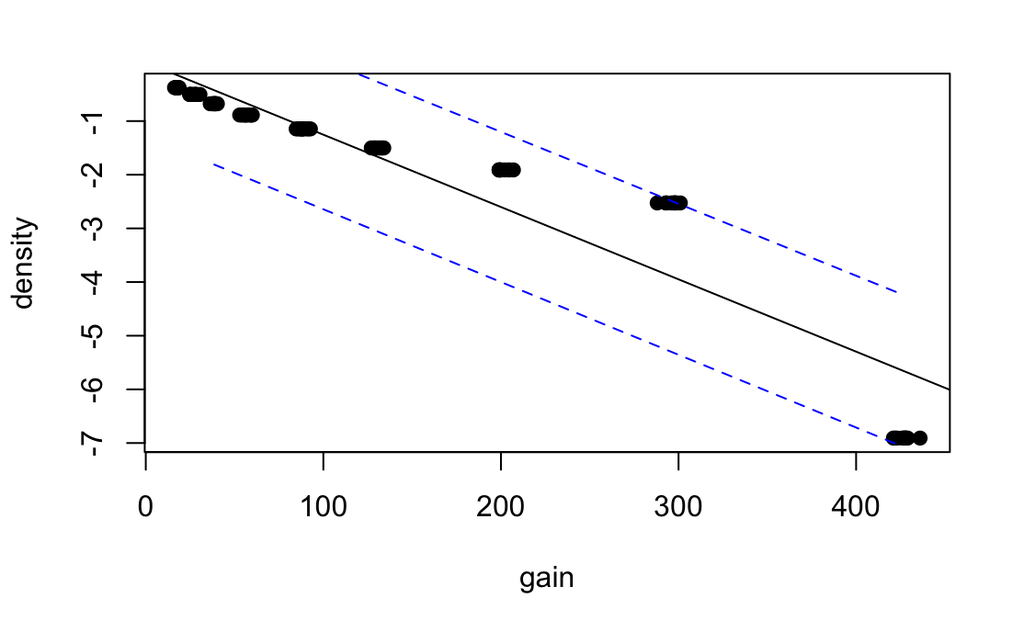

```r
lines(p2[,2]~ newdensity$gain,lty = 2,col = "blue")
lines(p2[,3]~ newdensity$gain,lty = 2,col = "blue")
```

### 2.6 Corss-Validation

SO as to avoid the condition that the measurement corresponding to the densities 0.508 and 0.001 were included in the fitting. Thus in this part, we will remove these data from the original data set then make a new predict.

Remove the 0.508 and 0.001

```r
setwd("~/Downloads")
dat <- read.table("gauge.txt", header=TRUE)
sub1 = subset(dat, dat$density != 0.508)
sub2 = subset(dat, dat$density != 0.001)
```

prediction for the subset 1

```r
# create the model
sub1density = sub1$density
sub1gain = sub1$gain
sub1_iLogm = lm(log(sub1density) ~ sub1gain, data = sub1)
summary(sub1_iLogm)
```

```
Call:
lm(formula = log(sub1density) ~ sub1gain, data = sub1)

Residuals:
    Min      1Q  Median      3Q     Max
-1.3056 -0.3024 -0.1853  0.2939  1.4343

Coefficients:
              Estimate Std. Error t value Pr(>|t|)
(Intercept)  0.1591790  0.1241015   1.283    0.203
sub1gain    -0.0136849  0.0006024 -22.717   <2e-16 ***
---
Signif. codes:  0 ‘***’ 0.001 ‘**’ 0.01 ‘*’ 0.05 ‘.’ 0.1 ‘ ’ 1

Residual standard error: 0.7277 on 78 degrees of freedom
Multiple R-squared:  0.8687,    Adjusted R-squared:  0.867
F-statistic: 516.1 on 1 and 78 DF,  p-value: < 2.2e-16
```

```r
# make the prediction
newset = data.frame(sub1gain = c(38.6))
sub1p <- predict(sub1_iLogm, newdata = newset, interval ="prediction")
exp(sub1p)
```

```
        fit       lwr      upr
1 0.6913853 0.1598598 2.990206
```

prediction for subset2

```r
# create the model
sub2density = sub2$density
sub2gain = sub2$gain
sub2_iLogm = lm(log(sub2density) ~ sub2gain, data = sub2)
summary(sub2_iLogm)
```

```
Call:
lm(formula = log(sub2density) ~ sub2gain, data = sub2)

Residuals:
      Min        1Q    Median        3Q       Max
-0.159267 -0.082428 -0.004974  0.088868  0.148180

Coefficients:
              Estimate Std. Error t value Pr(>|t|)
(Intercept) -0.3841150  0.0161395  -23.80   <2e-16 ***
sub2gain    -0.0075370  0.0001145  -65.82   <2e-16 ***
---
Signif. codes:  0 ‘***’ 0.001 ‘**’ 0.01 ‘*’ 0.05 ‘.’ 0.1 ‘ ’ 1

Residual standard error: 0.0939 on 78 degrees of freedom
Multiple R-squared:  0.9823,    Adjusted R-squared:  0.9821
F-statistic:  4332 on 1 and 78 DF,  p-value: < 2.2e-16
```

```r
# make the prediction
newset = data.frame(sub2gain = c(38.6))
sub2p <- predict(sub2_iLogm, newdata = newset, interval ="prediction")
exp(sub2p)
```

```
       fit       lwr       upr
1 0.509134 0.4215615 0.6148983
```

# 3 Advanced Analysis

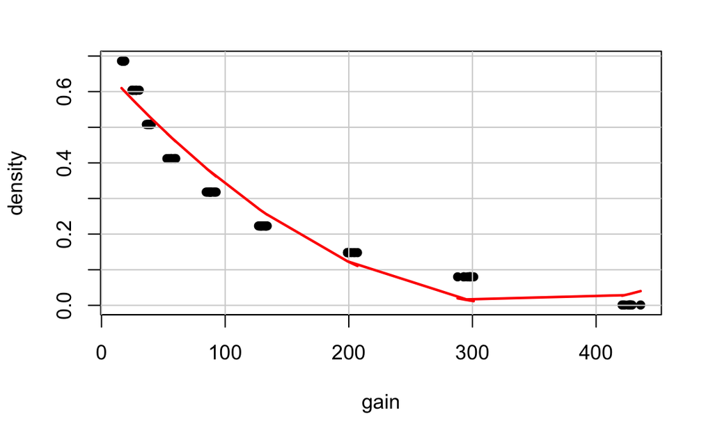

```r
# Quadratic model
m2 <- lm(density ~ gain + I(gain^2), data=dat)
plot(density ~ gain, data=CO2, pch=16); grid(lty='solid')
lines(predict(m2) ~ gain, data=dat, col='red', lwd=2)
```

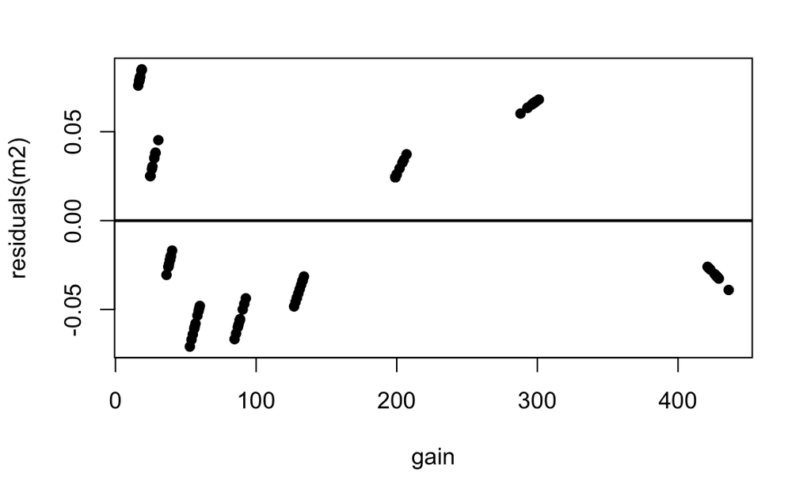

```r
plot(residuals(m2) ~ gain, data=dat, pch=16)
abline(h = 0, lwd = 2)
```

```r
summary(m2)
```

```
Call:
lm(formula = density ~ gain + I(gain^2), data = dat)

Residuals:
     Min       1Q   Median       3Q      Max
-0.07086 -0.04343 -0.02213  0.03776  0.08513

Coefficients:
              Estimate Std. Error t value Pr(>|t|)
(Intercept)  6.708e-01  1.110e-02   60.45   <2e-16 ***
gain        -3.844e-03  1.549e-04  -24.82   <2e-16 ***
I(gain^2)    5.499e-06  3.557e-07   15.46   <2e-16 ***
---
Signif. codes:  0 ‘***’ 0.001 ‘**’ 0.01 ‘*’ 0.05 ‘.’ 0.1 ‘ ’ 1

Residual standard error: 0.05076 on 87 degrees of freedom
Multiple R-squared:  0.9508,    Adjusted R-squared:  0.9497
F-statistic: 840.7 on 2 and 87 DF,  p-value: < 2.2e-16
```

```r
# make the prediction
newset_m2 = data.frame(gain = c(38.6))
predict(m2, newdata = newset_m2, interval ="prediction")
```

```
        fit       lwr       upr
1 0.5306438 0.4287201 0.6325675
```

```r
# residual between best expect and the real data
abs(0.53064383 - 0.508)
```

```
[1] 0.02264383
```

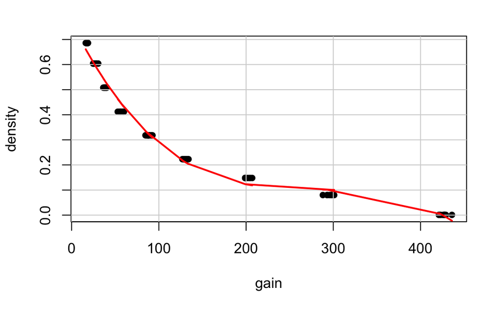

```r
# Cubic regression
m3 <- lm(density ~ gain + I(gain^2) + I(gain^3), data=dat)
plot(density ~ gain, data=dat, pch=16); grid(lty='solid')
lines(predict(m3) ~ gain, data=dat, col='red', lwd=2)
```

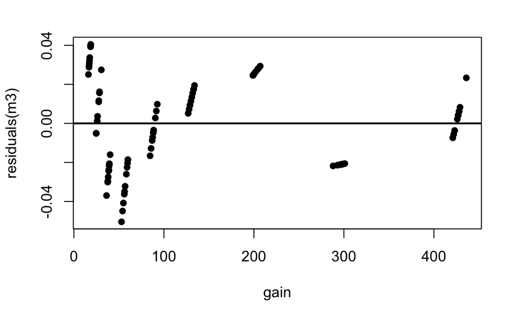

```r
plot(residuals(m3) ~ gain, data=dat, pch=16)
abline(h = 0, lwd = 2)
```

```r
summary(m3)
```

```
Call:
lm(formula = density ~ gain + I(gain^2) + I(gain^3), data = dat)

Residuals:
      Min        1Q    Median        3Q       Max
-0.050424 -0.020894  0.002485  0.018948  0.040488

Coefficients:
              Estimate Std. Error t value Pr(>|t|)
(Intercept)  7.681e-01  7.336e-03  104.70   <2e-16 ***
gain        -7.009e-03  1.870e-04  -37.49   <2e-16 ***
I(gain^2)    2.484e-05  1.071e-06   23.20   <2e-16 ***
I(gain^3)   -2.964e-08  1.621e-09  -18.28   <2e-16 ***
---
Signif. codes:  0 ‘***’ 0.001 ‘**’ 0.01 ‘*’ 0.05 ‘.’ 0.1 ‘ ’ 1

Residual standard error: 0.0231 on 86 degrees of freedom
Multiple R-squared:  0.9899,    Adjusted R-squared:  0.9896
F-statistic:  2818 on 3 and 86 DF,  p-value: < 2.2e-16
```

```r
# make the prediction
newset_m3 = data.frame(gain = c(38.6))
predict(m3, newdata = newset_m3, interval ="prediction")
```

```
        fit       lwr       upr
1 0.5328387 0.4864477 0.5792298
```

```r
# residual between best expect and the real data
abs(0.532838748 - 0.508)
```

```
[1] 0.02483875
```

The residual between real value and the best fit for log model

```r
0.654081341 - 0.508
```

```
[1] 0.1460813
```